# INET4061-Lab2

Mahsa Ayoughi

9/19/2019

## Overview

```r
require(ggplot2)
require(grid)
require (RCurl)
require(graphics)
```

## Data

### Probability Density Function

The PDF is the density of probability rather than the probability mass. The concept is very similar to mass density in physics: its unit is probability per unit length.

```r
mean = 0
sd=1
x <- seq(-4, 4, length=100)
PDF <- function (x, type= "norm", mean, sd){
    y <- dnorm(x, mean, sd)
    ggplot(x,y)

}
```

### Cumulative Distribution Function

The CDF determine the probability that an observation drawn from a distribution falls below a specified value. In essence, cdf() gives you the area under the distribution’s density curve to the left of a certain value on the x axis.

```r
x <- seq(-4, 4, length=100)
CDF <- function (x, mean, sd){
  y <- pnorm(x, mean, sd)
  plot2 <- ggplot (x,y)
  print (plot2)
}
```

### Inverse Cumulative Density Function

```r
ICDF <- function (x, mean, sd){
  y <- qnorm(x, mean, sd)
  plot3 <- ggplot (x,y)
  print (plot3)
}
```

### T Distribution

Code Resource: https://stat.ethz.ch/R-manual/R-devel/library/stats/html/TDist.html

```r
1 - pt(1:5, df = 1)
```

```
## [1] 0.25000000 0.14758362 0.10241638 0.07797913 0.06283296
```

```r
qt(.975, df = c(1:4,8,12,24))
```

```
## [1] 12.706205  4.302653  3.182446  2.776445  2.306004  2.178813  2.063899
```

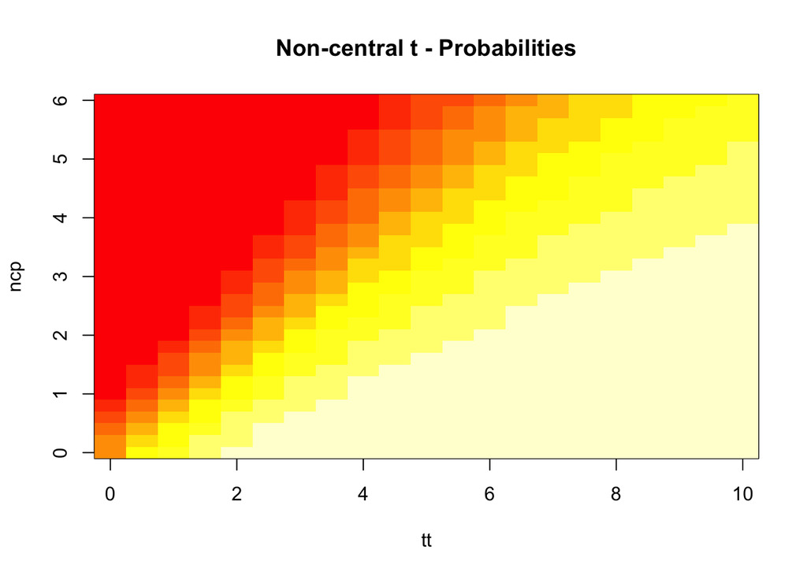

```r
tt <- seq(0, 10, len = 21)
ncp <- seq(0, 6, len = 31)
ptn <- outer(tt, ncp, function(t, d) pt(t, df = 3, ncp = d))
t.tit <- "Non-central t - Probabilities"
image(tt, ncp, ptn, zlim = c(0,1), main = t.tit)
```

## Conclusions

Question 2: What is the probability that the Z-score is within two standard deviations of the mean? Approximately 95% of the z-score will be within two standard deviations of the mean.